# Python_Final_Madduck_Case_Study

## A ) Deep Diving into Customer Churn

### 1. Preprocessing

```python
#loading necessary libraries
import pandas as pd
import numpy as np
import matplotlib.pyplot as plt
import seaborn as sns
import datetime
import warnings
warnings.filterwarnings('ignore')
pd.set_option('display.float_format', str)
```

```python
#reading the churn subscription table cohort data
churn_subs_table = pd.read_csv('Churn_Subs_Table_Cohort.csv')
```

```python
#reading the keyset data
key_df = pd.read_csv('Key Dataset.csv')
```

```python
# Filter for App Name which are call recorder, interview, scanner and fax
key_df_filtered = key_df[key_df['App Name'].isin(key_df['App Name'].unique()[:4])]
key_df_filtered.head()
```

|  | Original Start Date | App Name | App Apple ID | Country | Subscription Name | Subscription Apple ID | Standard Subscription Duration | Intro Type | Subscription Offer Duration | Subscription Offer Type | Customer Price | Customer Currency | Developer Proceeds | Proceeds Currency | trialPrice | trialCurrency | trialProceed | trialProceedCurrency |
| --- | --- | --- | --- | --- | --- | --- | --- | --- | --- | --- | --- | --- | --- | --- | --- | --- | --- | --- |
| 0 | 2021-10-16 | Call Recorder - Save & Listen | 1435773823.0 | AR | Call Recorder Month Trial V2 | 1446242014.0 | 1 Month | S | Non Duration | NaN | 12.99 | USD | 9.1 | USD | 0.0 | NaN | 0.0 | NaN |
| 1 | 2021-10-15 | Call Recorder - Save & Listen | 1435773823.0 | AU | Call Recorder Month | 1435776429.0 | 1 Month | S | Non Duration | NaN | 32.99 | AUD | 20.99 | AUD | 0.0 | NaN | 0.0 | NaN |
| 2 | 2021-10-15 | Interview & Meeting Recorder | 1505286803.0 | AU | Monthly one person v2 | 1535635450.0 | 1 Month | S | Non Duration | NaN | 48.99 | AUD | 31.18 | AUD | 0.0 | NaN | 0.0 | NaN |
| 3 | 2021-10-17 | Scanner Unlimited: Scan & Sign | 1439290223.0 | AU | Scanner Pro Year Trial | 1439369591.0 | 1 Year | S | Non Duration | NaN | 129.99 | AUD | 82.72 | AUD | 0.0 | NaN | 0.0 | NaN |
| 4 | 2021-10-17 | Fax - Scan PDF & Send Document | 1450601558.0 | AU | Fax Month v2 | 1548625377.0 | 1 Month | S | Non Duration | NaN | 42.99 | AUD | 27.36 | AUD | 0.0 | NaN | 0.0 | NaN |

```python
# Filter for churn subs table & keyset based on App Apple ID
churn_subs_table_filtered = churn_subs_table[churn_subs_table['App Apple ID'].isin(key_df_filtered['App Apple ID'].unique())]
```

```python
# Find Top 10 countries based on App Name which are Call Recorder and Interview Recorder
churn_subs_table_filtered_top10 = churn_subs_table_filtered[churn_subs_table_filtered['App Apple ID'].isin(key_df_filtered[key_df_filtered['App Name'].isin(key_df['App Name'].unique()[:2])]['App Apple ID'].unique())]
churn_subs_table_filtered_top10_by_country = churn_subs_table_filtered_top10[churn_subs_table_filtered_top10['Country Code'].isin(churn_subs_table_filtered_top10.groupby('Country Code').agg({'newSubs':'sum'}).sort_values(by='newSubs',ascending=False).head(10).index.values)]
```

```python
# Find Top 5 countries based on App Name which are Scanner and Fax
churn_subs_table_filtered_top5 = churn_subs_table_filtered[churn_subs_table_filtered['App Apple ID'].isin(key_df_filtered[key_df_filtered['App Name'].isin(key_df['App Name'].unique()[2:4])]['App Apple ID'].unique())]
churn_subs_table_filtered_top5_by_country = churn_subs_table_filtered_top5[churn_subs_table_filtered_top5['Country Code'].isin(churn_subs_table_filtered_top5.groupby('Country Code').agg({'newSubs':'sum'}).sort_values(by='newSubs',ascending=False).head(5).index.values)]
```

```python
# Concat all filter
churn_cohort_final = pd.concat([churn_subs_table_filtered_top5_by_country, churn_subs_table_filtered_top10_by_country])
```

```python
# Merge Churn subs table & keyset data
final_data = pd.merge(churn_cohort_final, key_df_filtered.drop_duplicates(['App Apple ID','App Name'])[['App Apple ID','App Name']], how="inner", on="App Apple ID")
```

```python
final_data['Original Start Date'] = pd.to_datetime(final_data['Original Start Date'])
final_data.head()
```

|  | Original Start Date | App Apple ID | Country Code | Package ID | Intro Duration | newSubs | Engagement | Total Churn | Cancel from Introductory | App Name |
| --- | --- | --- | --- | --- | --- | --- | --- | --- | --- | --- |
| 0 | 2019-12-30 | 1439290223 | IL | 1447548278 | 3 Days | 1 | 1 | 1 | 0 | Scanner Unlimited: Scan & Sign |
| 1 | 2019-12-24 | 1439290223 | IL | 1447548278 | 3 Days | 2 | 2 | 2 | 0 | Scanner Unlimited: Scan & Sign |
| 2 | 2019-12-28 | 1439290223 | IL | 1439369986 | 3 Days | 1 | 1 | 1 | 0 | Scanner Unlimited: Scan & Sign |
| 3 | 2020-01-03 | 1439290223 | IL | 1447548278 | 3 Days | 1 | 2 | 1 | 1 | Scanner Unlimited: Scan & Sign |
| 4 | 2020-01-05 | 1439290223 | IL | 1447548278 | 3 Days | 2 | 4 | 0 | 1 | Scanner Unlimited: Scan & Sign |

### 2. Exploratory Data Analysis

### 2.1. Churn Rate for the Last 15, 30, 45, 60, 90 and 180 Days

```python
# Found max Original Start Date in order to find last interval days
datasets=[]
IntervalDay = [15,30,45,60,90,180]

for i in final_data['Country Code'].unique():
    for lastdays in IntervalDay:

        for_churn_rate = final_data[(final_data['Country Code'] == i)]
        for_churn_rate = final_data[ final_data['Original Start Date'] >= (final_data['Original Start Date'].max() - datetime.timedelta(days=lastdays))]
        for_churn_rate['IntervalDay'] = lastdays
        # Calculated Churn Rate based on Total Churn and newSubs
        for_churn_rate = for_churn_rate.groupby(['Country Code','IntervalDay']).agg({'newSubs':'sum','Total Churn':'sum'})
        for_churn_rate['Churn Rate'] = for_churn_rate['Total Churn'] / for_churn_rate['newSubs']
        for_churn_rate=for_churn_rate.reset_index()
        # Appended Dataset
        for_churn_rate=for_churn_rate[['Country Code','IntervalDay','Churn Rate']]
        for_churn_rate =for_churn_rate.set_index(['Country Code','IntervalDay'])
        datasets.append(for_churn_rate)
```

```python
# Sorted Churn Rate & IntervalDay
churn_final = pd.concat(datasets)
churn_final = churn_final.reset_index()
churn_final = churn_final.drop_duplicates()
churn_final = churn_final.round(2)
churn_final = churn_final.sort_values(by=['Churn Rate','IntervalDay'],ascending=False)
churn_final.head()
```

|  | Country Code | IntervalDay | Churn Rate |
| --- | --- | --- | --- |
| 51 | CA | 180 | 0.79 |
| 56 | KR | 180 | 0.77 |
| 41 | CA | 90 | 0.69 |
| 46 | KR | 90 | 0.64 |
| 54 | IN | 180 | 0.63 |

```python
# Created Pivot Table for Churn Rates
pd.pivot_table(churn_final, values='Churn Rate', index=['Country Code', 'IntervalDay'],aggfunc=np.sum)
```

| Country Code | IntervalDay | Churn Rate |
| --- | --- | --- |
| AU | 15 | 0.1 |
|  | 30 | 0.25 |
|  | 45 | 0.39 |
|  | 60 | 0.43 |
|  | 90 | 0.51 |
|  | 180 | 0.58 |
| CA | 15 | 0.15 |
|  | 30 | 0.38 |
|  | 45 | 0.5 |
|  | 60 | 0.57 |
|  | 90 | 0.69 |
|  | 180 | 0.79 |
| GB | 15 | 0.16 |
|  | 30 | 0.3 |
|  | 45 | 0.44 |
|  | 60 | 0.48 |
|  | 90 | 0.53 |
|  | 180 | 0.57 |
| IL | 15 | 0.27 |
|  | 30 | 0.29 |
|  | 45 | 0.35 |
|  | 60 | 0.38 |
|  | 90 | 0.41 |
|  | 180 | 0.47 |
| IN | 15 | 0.23 |
|  | 30 | 0.29 |
|  | 45 | 0.36 |
|  | 60 | 0.43 |
|  | 90 | 0.49 |
|  | 180 | 0.63 |
| JP | 15 | 0.24 |
|  | 30 | 0.37 |
|  | 45 | 0.41 |
|  | 60 | 0.46 |
|  | 90 | 0.46 |
|  | 180 | 0.5 |
| KR | 15 | 0.29 |
|  | 30 | 0.37 |
|  | 45 | 0.4 |
|  | 60 | 0.5 |
|  | 90 | 0.64 |
|  | 180 | 0.77 |
| SA | 15 | 0.14 |
|  | 30 | 0.25 |
|  | 45 | 0.38 |
|  | 60 | 0.39 |
|  | 90 | 0.44 |
|  | 180 | 0.55 |
| TR | 15 | 0.18 |
|  | 30 | 0.24 |
|  | 45 | 0.45 |
|  | 60 | 0.51 |
|  | 90 | 0.56 |
|  | 180 | 0.63 |
| US | 15 | 0.13 |
|  | 30 | 0.23 |
|  | 45 | 0.36 |
|  | 60 | 0.42 |
|  | 90 | 0.53 |
|  | 180 | 0.63 |

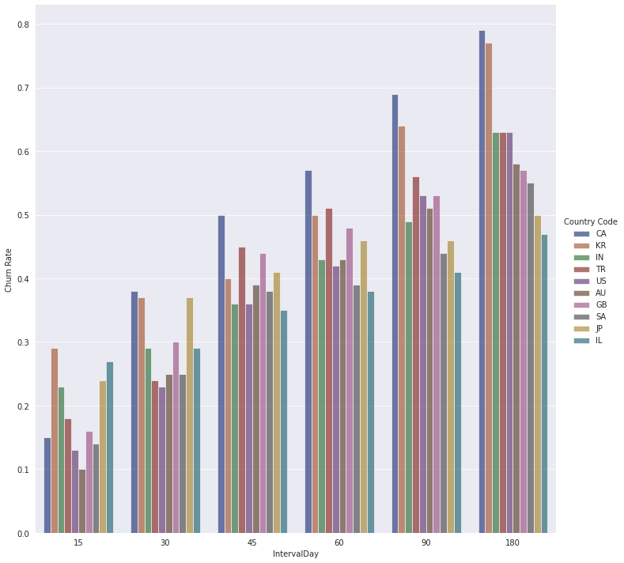

```python
# Visualization Churn Rate per Interval Day based on Country
vis_churn_rate = sns.catplot(
    data=churn_final, kind="bar",
    x="IntervalDay", y="Churn Rate", hue="Country Code",
    ci="sd", palette="dark", alpha=.6, height=6,size=10)
```

### 2.2. Variation of Churn Rates

```python
## Read the Churn Table data
churn_table = pd.read_csv('/content/Churn_Table_Cohort.csv')
```

```python
# Merged Churn_final data & Churn Table data
churn_table = pd.merge(churn_final, churn_table, on='Country Code', how="left")
churn_table.head()
```

|  | Country Code | IntervalDay | Churn Rate | Original Start Date | App Apple ID | Package ID | Type | Value |
| --- | --- | --- | --- | --- | --- | --- | --- | --- |
| 0 | CA | 180 | 0.79 | 2019-12-01 | 1435773823 | 1487914502 | C | 2 |
| 1 | CA | 180 | 0.79 | 2019-12-29 | 1435773823 | 1446241754 | C | 3 |
| 2 | CA | 180 | 0.79 | 2019-12-02 | 1435773823 | 1487914502 | C | 1 |
| 3 | CA | 180 | 0.79 | 2019-12-28 | 1439290223 | 1447548278 | C | 1 |
| 4 | CA | 180 | 0.79 | 2019-12-28 | 1435773823 | 1446241754 | C | 1 |

```python
# Filtered Churn Type based on B & C
churn_table_final = churn_table[(churn_table['Type']=='B') | (churn_table['Type']=='C')]
```

First of all, when we look at the variations, the country with the highest variation is Canada. Next I made a bar plot to check the distribution of number of types in each Country. Clearly the C type group(Voluntary Churn) outweighs B type group(Involuntary Churn). So we can say that most application in canada are with voluntary churn. This may be because the applications are made with poor quality, sold at high prices or due to application updates.

```python
churn_table_final.groupby(['Country Code','Type'])['Churn Rate'].var().sort_values(ascending=False)
```

```
Country Code  Type
CA            B        0.04351825343236568
              C       0.043490990512088684
US            B       0.028658410547640286
              C       0.028656252381068247
KR            B       0.027341845493562215
              C       0.027227638337048124
TR            B        0.02709377510040176
              C       0.027049915363934855
AU            B       0.025861945231350318
              C       0.025790645505528648
GB            B       0.020093611638203626
              C       0.020056839768628446
IN            B       0.017418057663125857
SA            B       0.017399888765294757
IN            C       0.017393089065183744
SA            C         0.0173815555299847
JP            B       0.007265995203836927
              C       0.007255914403943631
IL            B       0.004696209587513942
              C      0.0046808795366973565
Name: Churn Rate, dtype: float64
```

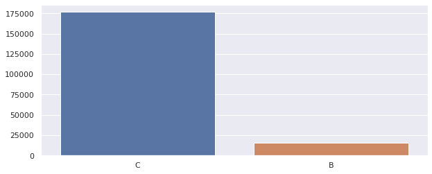

```python
total_types = churn_table_final.Type.value_counts()
sns.set_style("darkgrid")
plt.figure(figsize=(10,4))
sns.barplot(x=total_types.index, y=total_types.values)
plt.show()
```

### 2.3. Churn Patterns & Concentrations

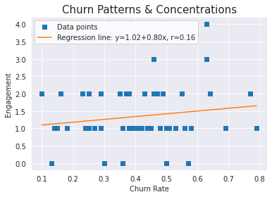

```python
import scipy
x5=churn_final['Churn Rate']
y5=final_data['Engagement'].head(60)

slope, intercept, r, *__ = scipy.stats.linregress(x5, y5)
line = f'Regression line: y={intercept:.2f}+{slope:.2f}x, r={r:.2f}'
fig, ax = plt.subplots()
ax.plot(x5, y5, linewidth=0, marker='s', label='Data points')
ax.plot(x5, intercept + slope * x5, label=line)
ax.set_xlabel('x5')
ax.set_ylabel('y5')
ax.legend(facecolor='white')
plt.xlabel("Churn Rate")
plt.ylabel("Engagement")
plt.title("Churn Patterns & Concentrations", fontsize=15)
plt.show()
```

### 2.4. Churn Patterns & Concentrations

```python
##add churn2
churn2_cohort = pd.read_csv('Churn2_Cohort.csv')
```

```python
churn2_cohort
```

|  | Original Start Date | AppID | Country Code | Package ID | Type | Period | Value |
| --- | --- | --- | --- | --- | --- | --- | --- |
| 0 | 2021-08-04 | 1435773823 | AR | 1435787587 | C | 0 | 1 |
| 1 | 2021-08-04 | 1505286803 | AR | 1535633619 | C | 0 | 1 |
| 2 | 2021-08-04 | 1435773823 | AR | 1435787587 | C | 1 | 1 |
| 3 | 2021-08-05 | 1435773823 | AR | 1435787587 | C | 0 | 2 |
| 4 | 2021-08-04 | 1435773823 | AU | 1435787587 | C | 0 | 2 |
| ... | ... | ... | ... | ... | ... | ... | ... |
| 143764 | 2021-12-10 | 1435773823 | US | 1508016473 | R | 36 | 1 |
| 143765 | 2022-01-14 | 1505286803 | US | 1535635450 | R | 1 | 1 |
| 143766 | 2021-10-14 | 1435773823 | US | 1435787587 | R | 93 | 1 |
| 143767 | 2021-10-29 | 1435773823 | US | 1435787587 | R | 78 | 1 |
| 143768 | 2022-01-07 | 1575519473 | US | 1576113398 | R | 8 | 1 |

143769 rows × 7 columns

```python
churn_cohort_final['Original Start Date'] = pd.to_datetime(churn_cohort_final['Original Start Date'])
```

```python
churn_cohort_test = churn_cohort_final[(churn_cohort_final['Original Start Date'] >= datetime.datetime(2021,1,1)) & (churn_cohort_final['Original Start Date'] < datetime.datetime(2022,1,1))]
```

```python
churn_cohort_test['Month'] = pd.DatetimeIndex(churn_cohort_test['Original Start Date']).month
churn_cohort_test
```

|  | Original Start Date | App Apple ID | Country Code | Package ID | Intro Duration | newSubs | Engagement | Total Churn | Cancel from Introductory | Month |
| --- | --- | --- | --- | --- | --- | --- | --- | --- | --- | --- |
| 41830 | 2021-01-01 | 1439290223 | CA | 1439370252 | Non Duration | 2 | 2 | 2 | 0 | 1 |
| 41834 | 2021-01-02 | 1439290223 | CA | 1439370252 | NaN | 1 | 1 | 1 | 0 | 1 |
| 41835 | 2021-01-02 | 1439290223 | CA | 1439369986 | 3 Days | 0 | 1 | 0 | 1 | 1 |
| 41841 | 2021-01-03 | 1439290223 | CA | 1439370252 | Non Duration | 2 | 2 | 2 | 0 | 1 |
| 41845 | 2021-01-03 | 1439290223 | CA | 1439369986 | 3 Days | 0 | 1 | 0 | 1 | 1 |
| ... | ... | ... | ... | ... | ... | ... | ... | ... | ... | ... |
| 90357 | 2021-01-07 | 1435773823 | IL | 1465872521 | NaN | 0 | 0 | 0 | 0 | 1 |
| 90366 | 2021-12-13 | 1435773823 | IL | 1435776429 | NaN | 0 | 0 | 0 | 0 | 12 |
| 90932 | 2021-10-11 | 1435773823 | US | 1508016473 | 1 Month | 0 | 0 | 0 | 0 | 10 |
| 90940 | 2021-12-10 | 1435773823 | US | 1446241754 | NaN | 0 | 0 | 0 | 0 | 12 |
| 90960 | 2021-10-24 | 1435773823 | US | 1508016473 | NaN | 0 | 0 | 0 | 0 | 10 |

14745 rows × 10 columns

App engagement is defined by a set of metrics that measure user interaction with an app. Common engagement metrics can include how many times a user opens the app, the duration of a usage session, and what actions a user takes within an app. As we seen below, first country in the list is U.S.A, and it has remarkable number of engagement. Second row belongs to Japan. Engagement trouble may be because there are too many notifications to customers. There are 3 ways to prevent churn based on engagement in these countries for me. First of all, fewer notifications should be sent to the customer, that is, almost no notifications should be sent, except for important notifications such as updates, customer interests etc. Secondly, Discounts, offers, and cupons plays critical role on customers. Finally, Don't beg to user for positive rating and don't irritate user by pop-ups asking for positive rating on App store. Don't neglect negative feedback/rating on app store and reply to them smartly.

```python
top_5_country_engagement = churn_cohort_test.groupby(['Country Code','Package ID']).agg({'Engagement':'sum'}).sort_values(by='Engagement',ascending=False).reset_index()
top_5_country_engagement.head()
```

|  | Country Code | Package ID | Engagement |
| --- | --- | --- | --- |
| 0 | US | 1435787587 | 14920 |
| 1 | JP | 1544690127 | 6657 |
| 2 | US | 1535633619 | 6352 |
| 3 | JP | 1446241754 | 5615 |
| 4 | IN | 1435787587 | 3442 |

### 2.5. Different Churn Metrics

```python
price = key_df_filtered.groupby(['Country', 'Original Start Date']).agg({'Customer Price':'sum', 'Developer Proceeds':'sum' }).sort_values(by='Customer Price',ascending=False).reset_index()
price .head()
```

|  | Country | Original Start Date | Customer Price | Developer Proceeds |
| --- | --- | --- | --- | --- |
| 0 | VN | 2021-10-14 | 2387000.0 | 1670900.0 |
| 1 | VN | 2021-08-11 | 2377000.0 | 1663900.0 |
| 2 | VN | 2021-07-23 | 1688000.0 | 1181600.0 |
| 3 | VN | 2021-09-29 | 1688000.0 | 1181600.0 |
| 4 | VN | 2021-07-04 | 1688000.0 | 1181600.0 |

## B) Retention Rates as an Outcome

### 2.6. Most Common Packages of Retention Rate based on New Subscription

As can be seen below, the two most-sold packages are the 1435787587 and 1487914502 packages, which are available in the USA and Japan. The retention rates of these packages are 0.2 and 0.11, respectively. The packages with the highest retention rate are the 1544690127 and 1446241754 packages in Japan and Israel. When we look at our two most-sold packages, their retention rates are lower than those of other packages, and this actually means that it is not important to sell the package a lot. Packages should be based on content and customer retention.

```python
packages_group = churn_cohort_test.groupby(['Country Code','Package ID']).agg({'newSubs':'sum','Total Churn':'sum'}).sort_values(by='newSubs',ascending=False).reset_index()

top2_packages = pd.concat([packages_group.groupby('Country Code').nth(0).reset_index(),packages_group.groupby('Country Code').nth(1).reset_index()])
```

```python
top2_packages['Living Subs'] = (top2_packages['newSubs'] - top2_packages['Total Churn'])
top2_packages['Retention Rate'] = (top2_packages['Living Subs'] / top2_packages['newSubs'])
top2_packages.sort_values(by='newSubs',ascending=False).reset_index()
```

|  | index | Country Code | Package ID | newSubs | Total Churn | Living Subs | Retention Rate |
| --- | --- | --- | --- | --- | --- | --- | --- |
| 0 | 9 | US | 1435787587 | 5323 | 4244 | 1079 | 0.2027052414052226 |
| 1 | 5 | JP | 1487914502 | 3395 | 3029 | 366 | 0.10780559646539029 |
| 2 | 9 | US | 1535633619 | 2154 | 540 | 1614 | 0.7493036211699164 |
| 3 | 5 | JP | 1544690127 | 1808 | 219 | 1589 | 0.8788716814159292 |
| 4 | 3 | IL | 1446241754 | 1092 | 166 | 926 | 0.847985347985348 |
| 5 | 8 | TR | 1487914502 | 916 | 839 | 77 | 0.08406113537117904 |
| 6 | 4 | IN | 1487914502 | 907 | 847 | 60 | 0.06615214994487321 |
| 7 | 1 | CA | 1435787587 | 760 | 725 | 35 | 0.046052631578947366 |
| 8 | 4 | IN | 1435787587 | 737 | 513 | 224 | 0.3039348710990502 |
| 9 | 8 | TR | 1435787587 | 647 | 432 | 215 | 0.3323029366306028 |
| 10 | 3 | IL | 1544690127 | 639 | 104 | 535 | 0.837245696400626 |
| 11 | 2 | GB | 1435787587 | 613 | 453 | 160 | 0.26101141924959215 |
| 12 | 1 | CA | 1487914502 | 564 | 547 | 17 | 0.030141843971631204 |
| 13 | 7 | SA | 1435787587 | 536 | 343 | 193 | 0.36007462686567165 |
| 14 | 0 | AU | 1435787587 | 450 | 362 | 88 | 0.19555555555555557 |
| 15 | 7 | SA | 1487914502 | 447 | 354 | 93 | 0.2080536912751678 |
| 16 | 0 | AU | 1535633619 | 437 | 89 | 348 | 0.7963386727688787 |
| 17 | 2 | GB | 1535633619 | 363 | 87 | 276 | 0.7603305785123967 |
| 18 | 6 | KR | 1487914502 | 228 | 229 | -1 | -0.0043859649122807015 |
| 19 | 6 | KR | 1435787587 | 153 | 140 | 13 | 0.08496732026143791 |

### 2.7. Calculate & Visualization Retention Rates

```python
## Calculate retention rate by using Churn_table_final data frame
new_churn_cohort = churn_table_final
new_churn_cohort['Original Start Date'] = pd.to_datetime(new_churn_cohort['Original Start Date'])
df = new_churn_cohort[(new_churn_cohort['Original Start Date'] >= datetime.datetime(2021,1,1)) & (new_churn_cohort['Original Start Date'] < datetime.datetime(2022,1,1))]
df['Living Subs'] = (churn_cohort_test['newSubs'] - churn_cohort_test['Total Churn'])
df['Retention Rates'] = (df['Living Subs'] / churn_cohort_test['newSubs'])

# Function that converts date to year month
import datetime as dt
def get_month(x):
    return dt.datetime(x.year, x.month, 1)

# Create the invoicemonth period column

df['InvoiceMonth'] = df['Original Start Date'].apply(get_month)
df.sort_values(by='Retention Rates',ascending=False).reset_index()
```

|  | index | Country Code | IntervalDay | Churn Rate | Original Start Date | App Apple ID | Package ID | Type | Value | Living Subs | Retention Rates | InvoiceMonth |
| --- | --- | --- | --- | --- | --- | --- | --- | --- | --- | --- | --- | --- |
| 0 | 60581 | US | 90 | 0.53 | 2021-12-10 | 1435773823 | 1465872521 | C | 18 | 1.0 | 1.0 | 2021-12-01 |
| 1 | 58145 | US | 90 | 0.53 | 2021-01-11 | 1435773823 | 1487914502 | B | 1 | 1.0 | 1.0 | 2021-01-01 |
| 2 | 58132 | US | 90 | 0.53 | 2021-03-08 | 1435773823 | 1487914502 | B | 1 | 2.0 | 1.0 | 2021-03-01 |
| 3 | 49300 | GB | 90 | 0.53 | 2021-09-14 | 1505286803 | 1562686293 | C | 2 | 1.0 | 1.0 | 2021-09-01 |
| 4 | 58133 | US | 90 | 0.53 | 2021-04-05 | 1435773823 | 1544690790 | B | 1 | 3.0 | 1.0 | 2021-04-01 |
| ... | ... | ... | ... | ... | ... | ... | ... | ... | ... | ... | ... | ... |
| 97309 | 243192 | AU | 15 | 0.1 | 2021-12-13 | 1435773823 | 1508016473 | C | 1 | nan | nan | 2021-12-01 |
| 97310 | 243196 | AU | 15 | 0.1 | 2021-07-13 | 1505286803 | 1535635450 | B | 1 | nan | nan | 2021-07-01 |
| 97311 | 243197 | AU | 15 | 0.1 | 2021-12-14 | 1435773823 | 1508016473 | C | 1 | nan | nan | 2021-12-01 |
| 97312 | 243200 | AU | 15 | 0.1 | 2021-11-14 | 1505286803 | 1505294299 | C | 1 | nan | nan | 2021-11-01 |
| 97313 | 243202 | AU | 15 | 0.1 | 2021-12-15 | 1435773823 | 1508016473 | C | 1 | nan | nan | 2021-12-01 |

97314 rows × 12 columns

```python
# Group by Retention Rates and select only the invoicemonth column

grouping = df.groupby('Retention Rates')['InvoiceMonth']

# Take the earliest date of each package and assign it back to the original dataset

df['CohortMonth'] = grouping.transform('min')
```

```python
# This function gets us the integer value of year and month

def get_date_int(df, column):
   year = df[column].dt.year
   month = df[column].dt.month
   return year, month

# Get the integers for the date parts from the 'InvoiceMonth' column

invoice_year, invoice_month = get_date_int(df, 'InvoiceMonth')

# Get the integers for date parts from the 'Cohortmonth' column

cohort_year, cohort_month = get_date_int(df, 'CohortMonth')

# Calculate difference in years

years_diff = invoice_year - cohort_year

# Calculate difference in months

months_diff = invoice_month - cohort_month

# Extract the difference in months from all previous values

df['CohortIndex'] = years_diff * 12 + months_diff + 1
df.head()
```

|  | Country Code | IntervalDay | Churn Rate | Original Start Date | App Apple ID | Package ID | Type | Value | Living Subs | Retention Rates | InvoiceMonth | CohortMonth | CohortIndex |
| --- | --- | --- | --- | --- | --- | --- | --- | --- | --- | --- | --- | --- | --- |
| 1329 | CA | 180 | 0.79 | 2021-01-01 | 1505286803 | 1535633619 | C | 3 | nan | nan | 2021-01-01 | NaT | nan |
| 1333 | CA | 180 | 0.79 | 2021-01-01 | 1435773823 | 1446241754 | C | 4 | nan | nan | 2021-01-01 | NaT | nan |
| 1334 | CA | 180 | 0.79 | 2021-01-02 | 1435773823 | 1446241754 | C | 4 | nan | nan | 2021-01-01 | NaT | nan |
| 1336 | CA | 180 | 0.79 | 2021-01-02 | 1505286803 | 1535633619 | C | 2 | nan | nan | 2021-01-01 | NaT | nan |
| 1338 | CA | 180 | 0.79 | 2021-01-02 | 1439290223 | 1439369986 | C | 1 | nan | nan | 2021-01-01 | NaT | nan |

```python
grouping = df.groupby(['CohortMonth', 'CohortIndex'])

# Count the number of unique values per Retention Rates

cohort_data = grouping['Retention Rates'].apply(pd.Series.nunique).reset_index()

# Create a pivot

cohort_counts = cohort_data.pivot(index='CohortMonth', columns='CohortIndex', values='Retention Rates')

# Select the first column and store it to cohort_sizes

cohort_sizes = cohort_counts.iloc[:,0]

# Divide the cohort count by cohort sizes along the rows

retention = cohort_counts.divide(cohort_sizes, axis=0)*100
retention
```

| CohortIndex CohortMonth | 1.0 | 2.0 | 3.0 | 4.0 | 5.0 | 6.0 | 7.0 | 8.0 | 9.0 | 10.0 | 11.0 | 12.0 |
| --- | --- | --- | --- | --- | --- | --- | --- | --- | --- | --- | --- | --- |
| 2021-01-01 | 100.0 | 55.319148936170215 | 53.191489361702125 | 46.808510638297875 | 48.93617021276596 | 53.191489361702125 | 48.93617021276596 | 51.06382978723404 | 46.808510638297875 | 53.191489361702125 | 46.808510638297875 | 48.93617021276596 |
| 2021-02-01 | 100.0 | 33.33333333333333 | 36.666666666666664 | 33.33333333333333 | 26.666666666666668 | 20.0 | 20.0 | 10.0 | 26.666666666666668 | 26.666666666666668 | 23.333333333333332 | nan |
| 2021-03-01 | 100.0 | 3.8461538461538463 | 15.384615384615385 | 11.538461538461538 | 23.076923076923077 | 7.6923076923076925 | 3.8461538461538463 | 11.538461538461538 | 30.76923076923077 | 15.384615384615385 | nan | nan |
| 2021-04-01 | 100.0 | nan | 42.857142857142854 | 28.57142857142857 | 28.57142857142857 | 14.285714285714285 | 42.857142857142854 | nan | 28.57142857142857 | nan | nan | nan |
| 2021-05-01 | 100.0 | 6.666666666666667 | 13.333333333333334 | 6.666666666666667 | 6.666666666666667 | 6.666666666666667 | 6.666666666666667 | nan | nan | nan | nan | nan |
| 2021-06-01 | 100.0 | 30.0 | 10.0 | nan | 10.0 | nan | nan | nan | nan | nan | nan | nan |
| 2021-07-01 | 100.0 | 27.27272727272727 | 9.090909090909092 | 9.090909090909092 | 9.090909090909092 | 9.090909090909092 | nan | nan | nan | nan | nan | nan |
| 2021-08-01 | 100.0 | 8.333333333333332 | 16.666666666666664 | 8.333333333333332 | 16.666666666666664 | nan | nan | nan | nan | nan | nan | nan |
| 2021-09-01 | 100.0 | nan | 20.0 | nan | nan | nan | nan | nan | nan | nan | nan | nan |
| 2021-10-01 | 100.0 | nan | nan | nan | nan | nan | nan | nan | nan | nan | nan | nan |
| 2021-11-01 | 100.0 | nan | nan | nan | nan | nan | nan | nan | nan | nan | nan | nan |
| 2021-12-01 | 100.0 | nan | nan | nan | nan | nan | nan | nan | nan | nan | nan | nan |

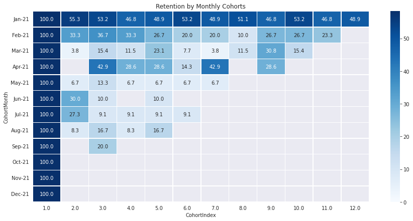

```python
# Create list of month names for visualisation

month_list = retention.reset_index()['CohortMonth']

def get_month_name(x):
   return dt.datetime.strftime(x, '%b-%y')

month_list = month_list.apply(get_month_name)

# Initialize inches plot figure

plt.figure(figsize=(15,7))

# Add a title

plt.title('Retention by Monthly Cohorts')

# Create the heatmap

sns.heatmap(data=retention,
annot = True,
cmap = "Blues",
vmin = 0.0,
vmax = list(retention.max().sort_values(ascending = False))[1]+3,
fmt = '.1f',
linewidth = 0.3,
yticklabels=month_list)
plt.show();
```

### 2.8. Predict Last 3 month Retention Rate based on Trends

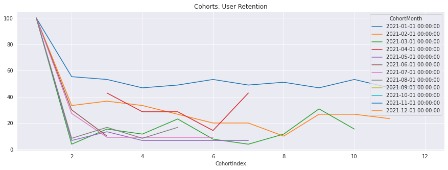

```python
cohorts_t = retention.transpose()
cohorts_t[cohorts_t.columns].plot(figsize=(15,5))
sns.set(style='whitegrid')
plt.title('Cohorts: User Retention')
plt.show()
```